# Assignment 1

umeshach

Monday, January 19, 2015

# Introduction

It is now possible to collect a large amount of data about personal movement using activity monitoring devices such as a Fitbit, Nike Fuelband, or Jawbone Up. These type of devices are part of the “quantified self” movement - a group of enthusiasts who take measurements about themselves regularly to improve their health, to find patterns in their behavior, or because they are tech geeks. But these data remain under-utilized both because the raw data are hard to obtain and there is a lack of statistical methods and software for processing and interpreting the data.

This assignment makes use of data from a personal activity monitoring device. This device collects data at 5 minute intervals through out the day. The data consists of two months of data from an anonymous individual collected during the months of October and November, 2012 and include the number of steps taken in 5 minute intervals each day.

# Data

The data for this assignment can be downloaded from the course web site:

Dataset: Activity monitoring data [52K] The variables included in this dataset are:

steps: Number of steps taking in a 5-minute interval (missing values are coded as NA)

date: The date on which the measurement was taken in YYYY-MM-DD format

interval: Identifier for the 5-minute interval in which measurement was taken

The dataset is stored in a comma-separated-value (CSV) file and there are a total of 17,568 observations in this dataset.

```r
library(knitr)
opts_chunk$set(echo = TRUE, results = 'hold')
```

Loading and preprocessing the data

```r
data <- read.csv("activity.csv",header=T, colClasses = c("integer", "Date", "factor"))
data$month <- as.numeric(format(data$date, "%m"))
data$day <- as.numeric(format(data$date, "%d"))
```

remove data with NA value and create newdata set

```r
newdata <- na.omit(data)
rownames(newdata) <- 1:nrow(newdata)
head(newdata)
dim(newdata)
```

```
##   steps       date interval month day
## 1     0 2012-10-02        0    10   2
## 2     0 2012-10-02        5    10   2
## 3     0 2012-10-02       10    10   2
## 4     0 2012-10-02       15    10   2
## 5     0 2012-10-02       20    10   2
## 6     0 2012-10-02       25    10   2
## [1] 15264     5
```

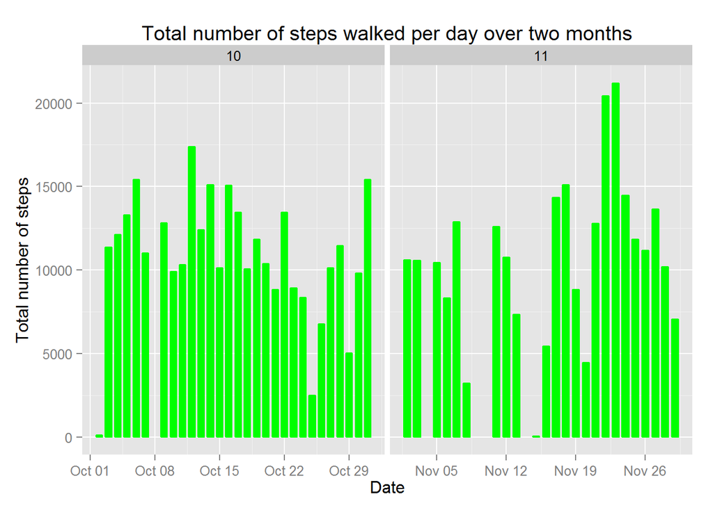

```r
library(ggplot2)
ggplot(newdata, aes(date, steps)) + geom_bar(stat = "identity", colour = "green", fill = "green", width = 0.7) + facet_grid(. ~ month, scales = "free") + labs(title = "Total number of steps walked per day over two months", x = "Date", y = "Total number of steps")
```

total, mean and median number of step walked each day

```r
SumSteps <- aggregate(newdata$steps, list(Date = newdata$date), FUN = "sum")$x
mean(SumSteps)
median(SumSteps)
```

```
## [1] 10766.19
## [1] 10765
```

# What is the average daily activity pattern?

create a line plot (i.e. type = “l”) of the 5-minute interval (x-axis) and the average number of steps taken, averaged across all days (y-axis)

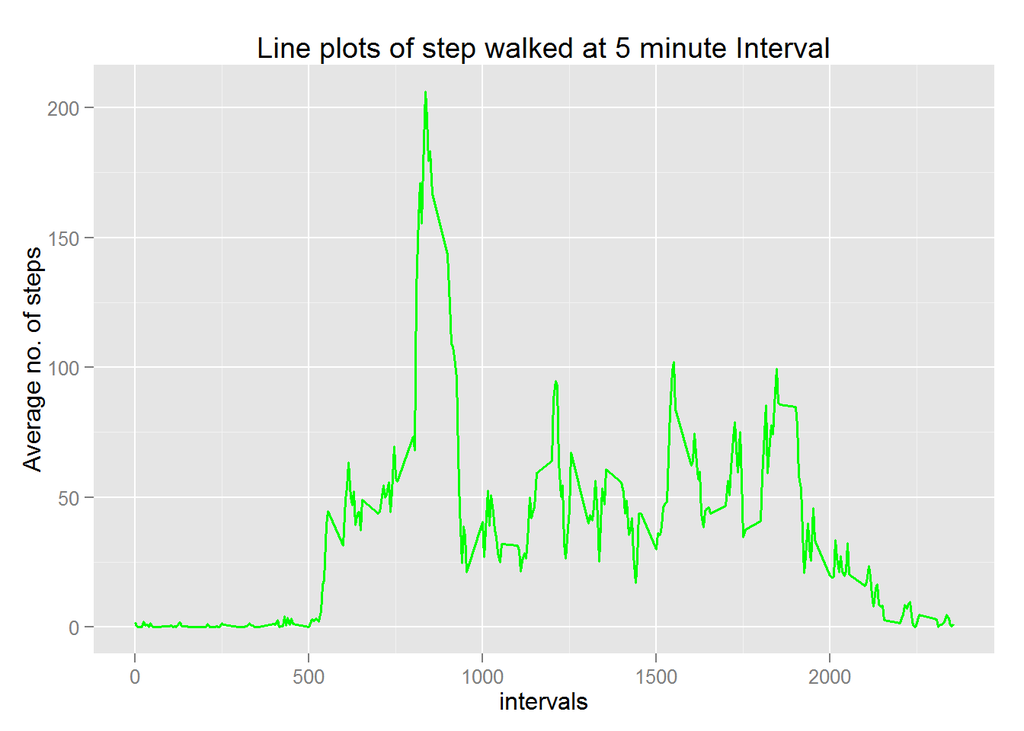

```r
MeanSteps <- aggregate(newdata$steps, list(interval = as.numeric(as.character(newdata$interval))), FUN = "mean")
names(MeanSteps)[2] <- "meanOfSteps"
ggplot(MeanSteps, aes(interval, meanOfSteps)) + geom_line(color = "green", size = 0.6) + labs(title = "Line plots of step walked at 5 minute Interval", x = "intervals", y = "Average no. of steps")
```

identify 5-minute interval with maximu no of steps travelled in a aday contains the maximum number of steps?

```r
MeanSteps[MeanSteps$meanOfSteps == max(MeanSteps$meanOfSteps), ]
```

```
##     interval meanOfSteps
## 104      835    206.1698
```

# imputing missing values

```r
missing_vals <- sum(is.na(data$steps))
newData <- data
for (i in 1:nrow(newData)) {
  if (is.na(newData$steps[i])) {
    newData$steps[i] <- MeanSteps[which(newData$interval[i] == MeanSteps$interval), ]$meanOfSteps
  }
}
```

dimention and missing value check for new data set

```r
head(newData)
sum(is.na(newData))
head(newData)
sum(is.na(newData))
```

```
##       steps       date interval month day
## 1 1.7169811 2012-10-01        0    10   1
## 2 0.3396226 2012-10-01        5    10   1
## 3 0.1320755 2012-10-01       10    10   1
## 4 0.1509434 2012-10-01       15    10   1
## 5 0.0754717 2012-10-01       20    10   1
## 6 2.0943396 2012-10-01       25    10   1
## [1] 0
##       steps       date interval month day
## 1 1.7169811 2012-10-01        0    10   1
## 2 0.3396226 2012-10-01        5    10   1
## 3 0.1320755 2012-10-01       10    10   1
## 4 0.1509434 2012-10-01       15    10   1
## 5 0.0754717 2012-10-01       20    10   1
## 6 2.0943396 2012-10-01       25    10   1
## [1] 0
```

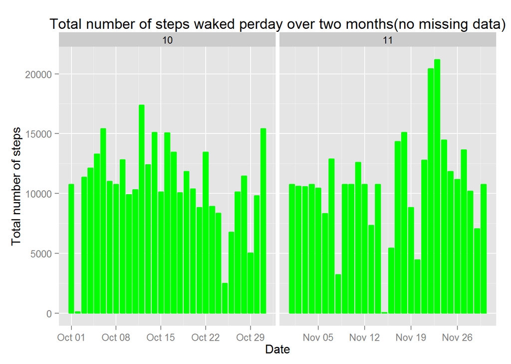

```r
ggplot(newData, aes(date, steps)) + geom_bar(stat = "identity",
                                             colour = "green",
                                             fill = "green",
                                             width = 0.8) + facet_grid(. ~ month, scales = "free") + labs(title = "Total number of steps waked perday over two months(no missing data)", x = "Date", y = "Total number of steps")
```

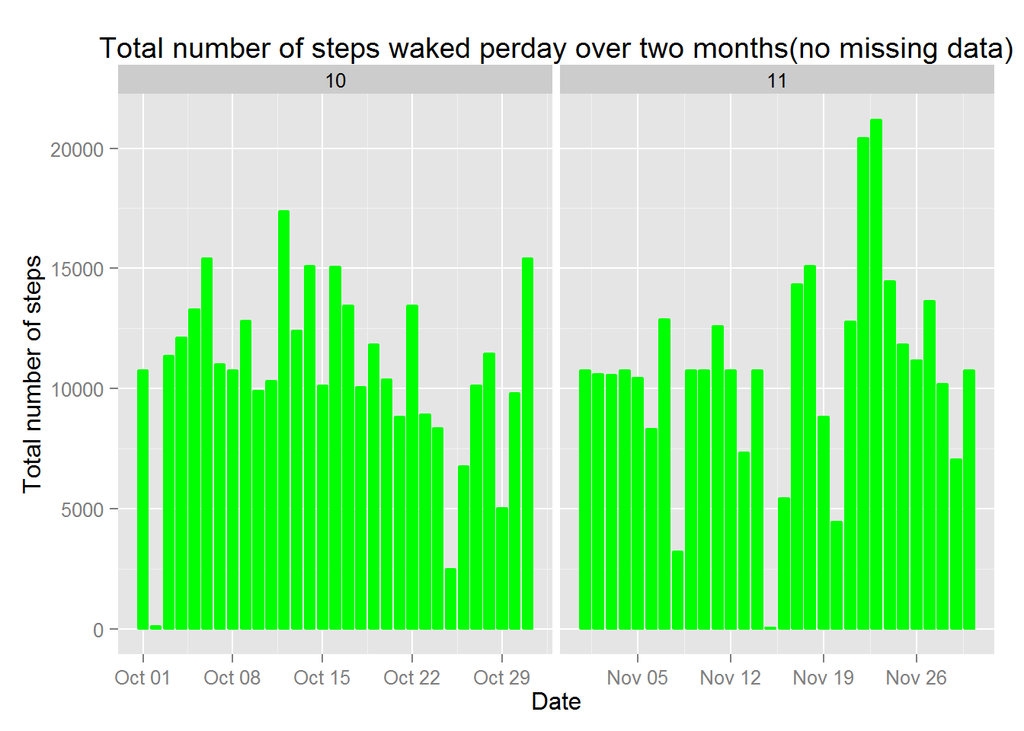

```r
ggplot(newData, aes(date, steps)) + geom_bar(stat = "identity",
                                             colour = "green",
                                             fill = "green",
                                             width = 0.8) + facet_grid(. ~ month, scales = "free") + labs(title = "Total number of steps waked perday over two months(no missing data)", x = "Date", y = "Total number of steps")
```

Compare imputed data set with original data set (with missing values)

```r
imputedTotalSteps <- aggregate(newData$steps,
                           list(Date = newData$date),
                           FUN = "sum")$x
newMean <- mean(imputedTotalSteps)
newMean
newMedian<-median(imputedTotalSteps)
newMedian

oldMean <- mean(SumSteps)
oldMedian <- median(SumSteps)
newMean - oldMean
newMedian - oldMedian
```

```
## [1] 10766.19
## [1] 10766.19
## [1] 0
## [1] 1.188679
```

# Are there differences in activity patterns between weekdays and weekends?

First create a new variable with 2 factor level: weekdays and weekend

```r
newData$weekdays <- factor(format(newData$date, "%A"))
levels(newData$weekdays)
levels(newData$weekdays) <- list(weekday = c("Monday", "Tuesday",
                                             "Wednesday",
                                             "Thursday", "Friday"),
                                 weekend = c("Saturday", "Sunday"))
levels(newData$weekdays)
```

```
## [1] "Friday"    "Monday"    "Saturday"  "Sunday"    "Thursday"  "Tuesday"
## [7] "Wednesday"
## [1] "weekday" "weekend"
```

create a panel plot of weekdays and weekend to compare difference in activity pattern

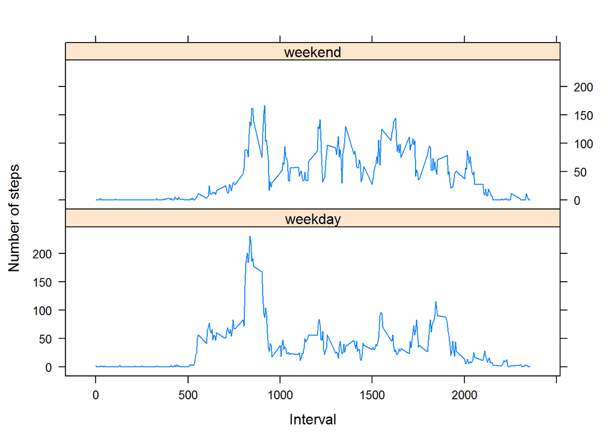

```r
avgSteps <- aggregate(newData$steps,
                      list(interval = as.numeric(as.character(newData$interval)),
                           weekdays = newData$weekdays),
                      FUN = "mean")
names(avgSteps)[3] <- "meanOfSteps"
library(lattice)
xyplot(avgSteps$meanOfSteps ~ avgSteps$interval | avgSteps$weekdays,
       layout = c(1, 2), type = "l",
       xlab = "Interval", ylab = "Number of steps")
```

```r
table(newData$weekdays)
```

```
##
## weekday weekend
##   12960    4608
```